# Chapter3

## What’s the Chapter about?

## Easy Questions

```r
p_grid <- seq( from=0 , to=1 , length.out=1000 )
prior <- rep( 1 , 1000 )
likelihood <- dbinom( 6 , size=9 , prob=p_grid )
posterior <- likelihood * prior
posterior <- posterior / sum(posterior)
set.seed(100)
samples <- sample( p_grid , prob=posterior , size=1e4 , replace=TRUE )
```

### 3E1.

How much posterior probability lies below p = 0.2?

```r
sum(samples < 0.2)/length(samples)
```

```
## [1] 4e-04
```

Ans: 0.04%

### 3E2.

How much posterior probability lies above p = 0.8?

```r
sum(samples > 0.8)/length(samples)
```

```
## [1] 0.1116
```

Ans: 11.16%

### 3E3.

How much posterior probability lies between p = 0.2 and p = 0.8?

```r
sum(samples > 0.2 & samples < 0.8)/length(samples)
```

```
## [1] 0.888
```

Ans 88.8%

### 3E4.

20% of the posterior probability lies below which value of p?

```r
quantile(samples, 0.2)
```

```
##       20%
## 0.5185185
```

Ans: 0.5185185

### 3E5.

20% of the posterior probability lies above which value of p?

Rephrase questions as 80% probaability lies *below* p.

```r
quantile(samples, 0.8)
```

```
##       80%
## 0.7557558
```

Ans: 0.7557558

### 3E6.

Which values of p contain the narrowest interval equal to 66% of the posterior probability?

Using the Highest Posterior Density Interval function from the rethinking package, we get:

```r
rethinking::HPDI(samples, prob=0.66)
```

```
##     |0.66     0.66|
## 0.5085085 0.7737738
```

Ans: [0.5085085, 0.7737738]

### 3E7.

Which values of p contain 66% of the posterior probability, assuming equal posterior probability both below and above the interval?

Using the Posterior Interval function from the rethinking package, we get:

```r
rethinking::PI(samples, prob=0.66)
```

```
##       17%       83%
## 0.5025025 0.7697698
```

Ans: [0.5025025,0.7697698]

## Medium Questions

### 3M1.

Suppose the globe tossing data had turned out to be 8 water in 15 tosses. Construct the poste- rior distribution, using grid approximation. Use the same flat prior as before.

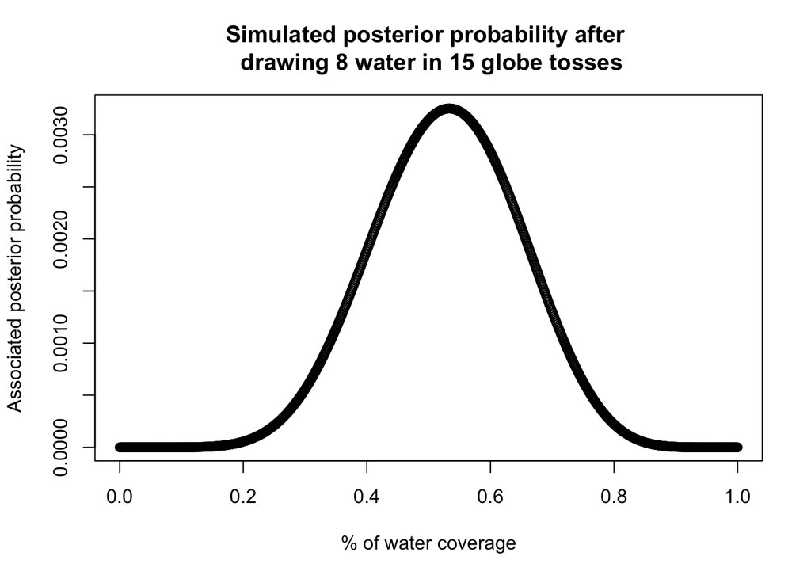

```r
p_grid <- seq( from=0 , to=1 , length.out=1000 )
prior <- rep( 1 , 1000 )
likelihood <- dbinom( 8 , size=15 , prob=p_grid )
posterior <- likelihood * prior
posterior <- posterior / sum(posterior)
plot(x=p_grid, y=posterior, xlab = "% of water coverage", ylab = "Associated posterior probability", main = "Simulated posterior probability after \n drawing 8 water in 15 globe tosses")
```

### 3M2.

Draw 10,000 samples from the grid approximation from above. Then use the samples to cal- culate the 90% HPDI for p.

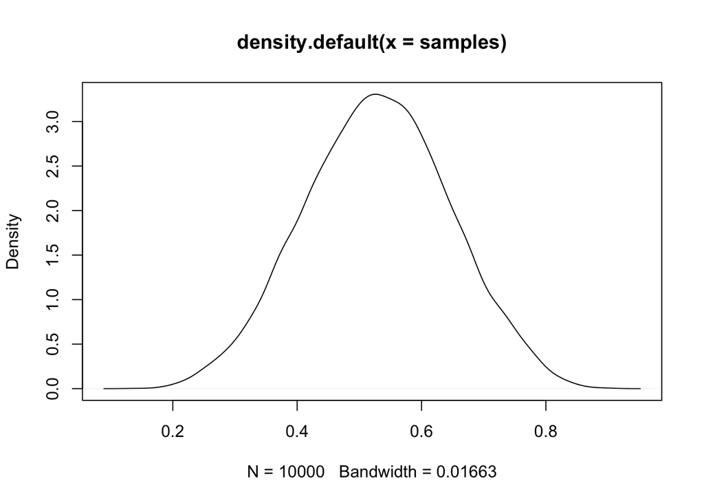

```r
set.seed(100)
samples <- sample( p_grid , prob=posterior , size=1e4 , replace=TRUE )
plot(density(samples))
```

```r
rethinking::HPDI(samples, prob=0.90)
```

```
##      |0.9      0.9|
## 0.3343343 0.7217217
```

Ans: [0.3343343, 0.7217217]

### 3M3.

Construct a posterior predictive check for this model and data. This means simulate the distribution of samples, averaging over the posterior uncertainty in p. What is the probability of observing 8 water in 15 tosses?

```r
p_grid <- seq( from=0 , to=1 , length.out=1000 )
prior <- rep( 1 , 1000 )
likelihood <- dbinom( 8 , size=15 , prob=p_grid )
posterior <- likelihood * prior
posterior <- posterior / sum(posterior)
set.seed(100)
samples <- sample( p_grid , prob=posterior , size=1e4 , replace=TRUE )
```

I think what McL is trying to do is something like

$$P(X=8) = \sum_{\theta}(P(x = 8| \theta) \space P(\theta))$$
But, the path to demonstrate this feels a bit circuitous. $P(\theta)$ gets incorporated into out calcs via the `samples` from the prior_grid we pick above. $(P(x = 8| \theta)$ gets incorporated via the simulated_samples we generate using `rbinom` below.

So, in effect, what we do is: 1. Pick N samples of $\theta$, where each value is picked with probability equal to the posterior probability of the value. So, you end up with a vector of length N, where each theta value appears $N*P(\theta)$ times. 2. We then feed these N samples of $\theta$ to `rbinom` with 15 trials. For each value of theta, the `rbinom` function outputs the expected number of successes. 3. We then check the proportion of samples returning 8 successes.

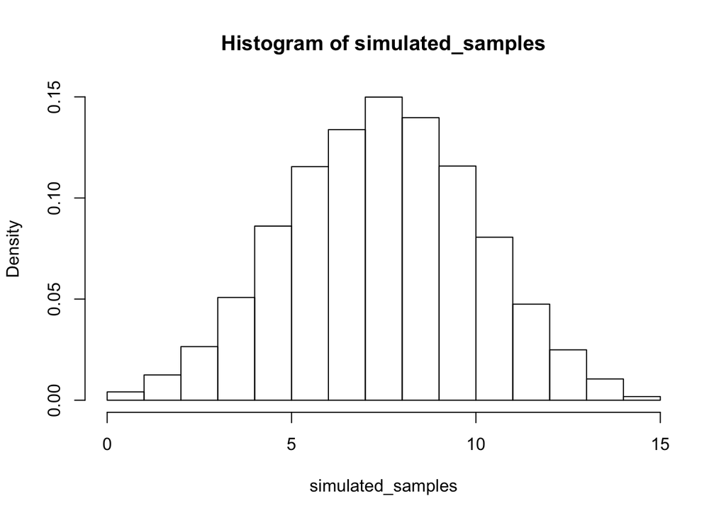

```r
simulated_samples <- rbinom(1e4,15,samples)
hist(simulated_samples,freq = FALSE)
```

```r
print(sum(simulated_samples == 8 )/length(simulated_samples))
```

```
## [1] 0.1499
```

```r
length = 1e4
p_grid <- seq( from=0 , to=1 , length.out=length )
prior <- rep( 1 , length)
likelihood <- dbinom( 8 , size=15 , prob=p_grid )
posterior <- likelihood * prior
posterior <- posterior / sum(posterior)
```

```r
sum = 0
for (i in 1:length){
  theta <- p_grid[i]
  p_theta <- posterior[i]
  sum = sum + dbinom(8,15,theta)*p_theta
}
print(sum)
```

```
## [1] 0.1469682
```

### 3M4.

Using the posterior distribution constructed from the new (8/15) data, now calculate the probability of observing 6 water in 9 tosses.

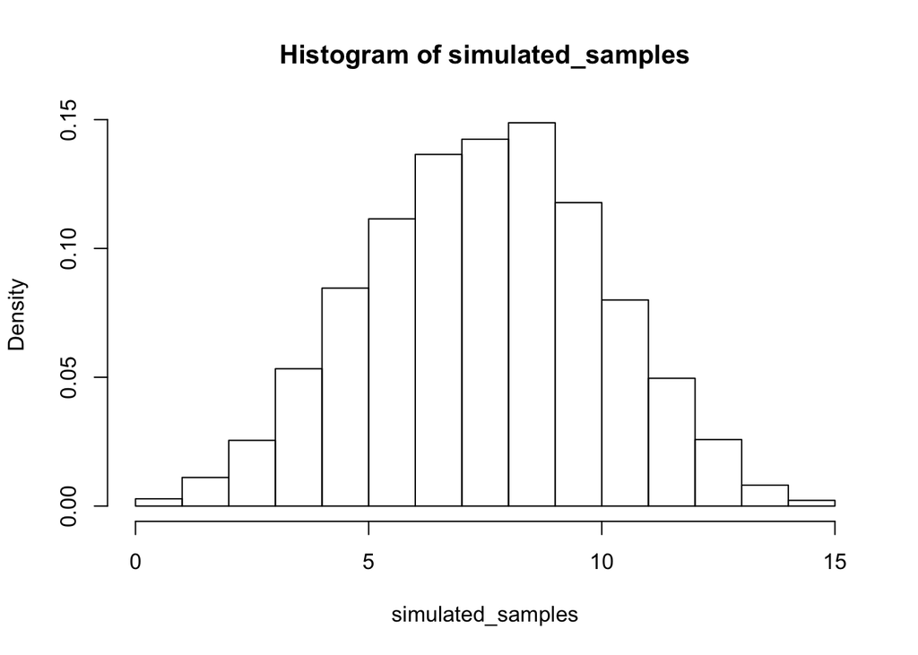

```r
simulated_samples <- rbinom(1e4,15,samples)
hist(simulated_samples,freq = FALSE)
```

```r
print(sum(simulated_samples == 6 )/length(simulated_samples))
```

```
## [1] 0.1115
```

```r
length = 1e4
p_grid <- seq( from=0 , to=1 , length.out=length )
prior <- rep( 1 , length)
likelihood <- dbinom( 8 , size=15 , prob=p_grid )
posterior <- likelihood * prior
posterior <- posterior / sum(posterior)

sum = 0
for (i in 1:length){
  theta <- p_grid[i]
  p_theta <- posterior[i]
  sum = sum + dbinom(6,15,theta)*p_theta
}
print(sum)
```

```
## [1] 0.1143086
```

### 3M5.

Startoverat 3M1, but now use a prior that is zero below p=0.5 and a constant above p=0.5. This corresponds to prior information that a majority of the Earth’s surface is water. Repeat each problem above and compare the inferences. What difference does the better prior make? If it helps, compare inferences (using both priors) to the true value p = 0.7.

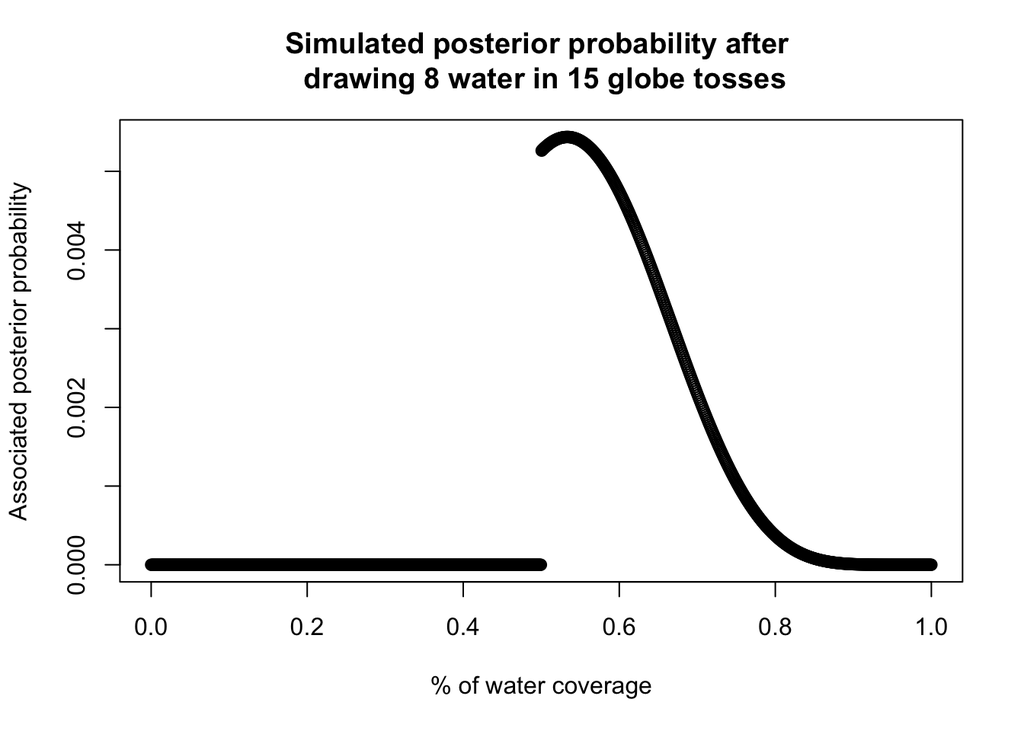

```r
p_grid <- seq( from=0 , to=1 , length.out=1000 )
prior <- ifelse(p_grid < 0.5, 0, 2)
likelihood <- dbinom( 8 , size=15 , prob=p_grid )
posterior <- likelihood * prior
posterior <- posterior / sum(posterior)
plot(x=p_grid, y=posterior, xlab = "% of water coverage", ylab = "Associated posterior probability", main = "Simulated posterior probability after \n drawing 8 water in 15 globe tosses")
```

```r
set.seed(100)
samples <- sample( p_grid , prob=posterior , size=1e4 , replace=TRUE )
rethinking::HPDI(samples, prob=0.90)
```

```
##      |0.9      0.9|
## 0.5005005 0.7097097
```

Probability of getting 8 tosses water. = 15%

```r
sum = 0
for (i in 1:length(p_grid)){
  theta <- p_grid[i]
  p_theta <- posterior[i]
  sum = sum + dbinom(8,15,theta)*p_theta
}
print(sum)
```

```
## [1] 0.1572281
```

Probability of getting 6 tosses water. = 6%

```r
sum = 0
for (i in 1:length(p_grid)){
  theta <- p_grid[i]
  p_theta <- posterior[i]
  sum = sum + dbinom(6,15,theta)*p_theta
}
print(sum)
```

```
## [1] 0.06880203
```

### 3M6.

Suppose you want to estimate the Earth’s proportion of water very precisely. Specifically, you want the 99% percentile interval of the posterior distribution of p to be only 0.05 wide. This means the distance between the upper and lower bound of the interval should be 0.05. How many times will you have to toss the globe to do this?

Approaches:

1. Brute force: Write a function that calculates the PI interval width, and iterate it over sample sizes Complications: Depends on priors, and true probability, I suppose
2. Analytical: Somehow express PI width as a function of true probability and sample size?

## Hard Questions

Introduction. The practice problems here all use the data below. These data indicate the gender (male=1, female=0) of officially reported first and second born children in 100 two-child families.So for example, the first family in the data reported a boy (1) and then a girl (0). The second family reported a girl (0) and then a boy (1). The third family reported two girls.

```r
birth1 <- c(1,0,0,0,1,1,0,1,0,1,0,0,1,1,0,1,1,0,0,0,1,0,0,0,1,0,
0,0,0,1,1,1,0,1,0,1,1,1,0,1,0,1,1,0,1,0,0,1,1,0,1,0,0,0,0,0,0,0,
1,1,0,1,0,0,1,0,0,0,1,0,0,1,1,1,1,0,1,0,1,1,1,1,1,0,0,1,0,1,1,0,
1,0,1,1,1,0,1,1,1,1)

birth2 <- c(0,1,0,1,0,1,1,1,0,0,1,1,1,1,1,0,0,1,1,1,0,0,1,1,1,0,
1,1,1,0,1,1,1,0,1,0,0,1,1,1,1,0,0,1,0,1,1,1,1,1,1,1,1,1,1,1,1,1,
1,1,1,0,1,1,0,1,1,0,1,1,1,0,0,0,0,0,0,1,0,0,0,1,1,0,0,1,0,0,1,1,
0,0,0,1,1,1,0,0,0,0)
```

### 3H1.

Using grid approximation, compute the posterior distribution for the probability of a birth being a boy. Assume a uniform prior probability. Which parameter value maximizes the posterior probability?

```r
p_grid <- seq( from=0 , to=1 , length.out=1000 )
prior <- rep( 1 , 1000 )
n_births <- 100
likelihood <- dbinom( sum(birth1 + birth2) , size= 2*n_births, prob=p_grid )
posterior <- likelihood * prior
posterior <- posterior / sum(posterior)
```

```r
p_grid[which.max(posterior)]
```

```
## [1] 0.5545546
```

Ans: Probability of birth being boy = 0.5545546 maximises the posterior.

### 3H2.

Using the sample function, draw 10,000 random parameter values from the posterior distri- bution you calculated above. Use these samples to estimate the 50%, 89%, and 97% highest posterior density intervals.

```r
set.seed(100)
samples <- sample( p_grid , prob=posterior , size=1e4 , replace=TRUE )
```

```r
rethinking::HPDI(samples, prob=c(0.50, 0.89, 0.97))
```

```
##     |0.97     |0.89      |0.5      0.5|     0.89|     0.97|
## 0.4824825 0.4994995 0.5265265 0.5725726 0.6076076 0.6296296
```

Ans:  
|0.97 |0.89 |0.5 0.5| 0.89| 0.97| 0.4824825 0.4994995 0.5265265 0.5725726 0.6076076 0.6296296

### 3H3.

Use rbinom to simulate 10,000 replicates of 200 births. You should end up with 10,000 num- bers, each one a count of boys out of 200 births. Compare the distribution of predicted numbers of boys to the actual count in the data (111 boys out of 200 births). There are many good ways to visualize the simulations, but the dens command (part of the rethinking package) is probably the easiest way in this case. Does it look like the model fits the data well? That is, does the distribution of predictions include the actual observation as a central, likely outcome?

```r
births_H3 <- rbinom(1e4, 200,prob = 0.5545546)
```

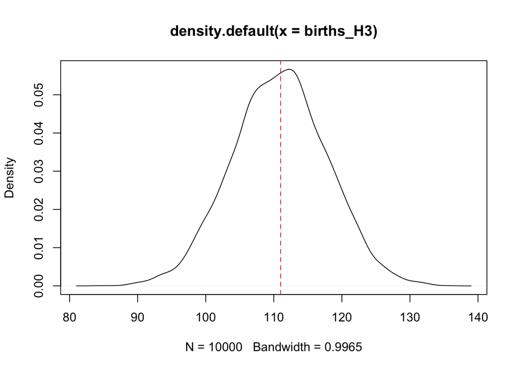

```r
plot(density(births_H3))
abline(v=111, col="red",lty=2)
```

Ans: Yeah, looks like a good fit, IMO.

### 3H4.

Now compare 10,000 counts of boys from 100 simulated first borns only to the number of boys in the first births, birth1. How does the model look in this light?

```r
births_H4 <- rbinom(1e4, 100,prob = 0.5545546)
actual_boys_H4 <- sum(birth1)
```

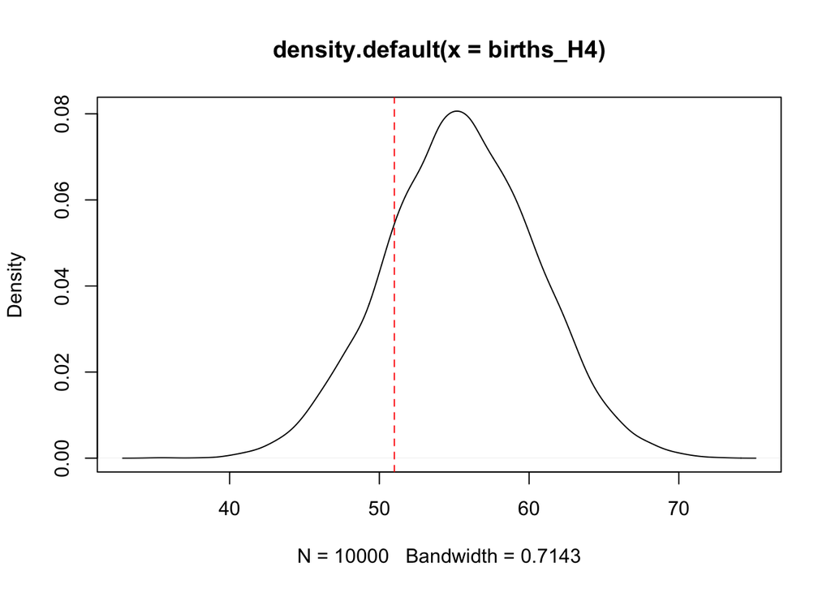

```r
plot(density(births_H4))
abline(v=actual_boys_H4, col="red",lty=2)
```

### 3H5.

The model assumes that sex of first and second births are independent. To check this assumption, focus now on second births that followed female first borns. Compare 10,000 simulated counts of boys to only those second births that followed girls. To do this correctly, you need to count the number of first borns who were girls and simulate that many births, 10,000 times. Compare the counts of boys in your simulations to the actual observed count of boys following girls. How does the model look in this light? Any guesses what is going on in these data?

```r
female_first_borns <- which(birth1 == 0)
births_post_female <- birth2[female_first_borns]
actual_boys_2ndborn <- sum(births_post_female)
```

```r
births_H5 <- rbinom(1e4, length(female_first_borns), prob = 0.5545546)
simulated_boys_2ndborn <- mean(births_H5)
```

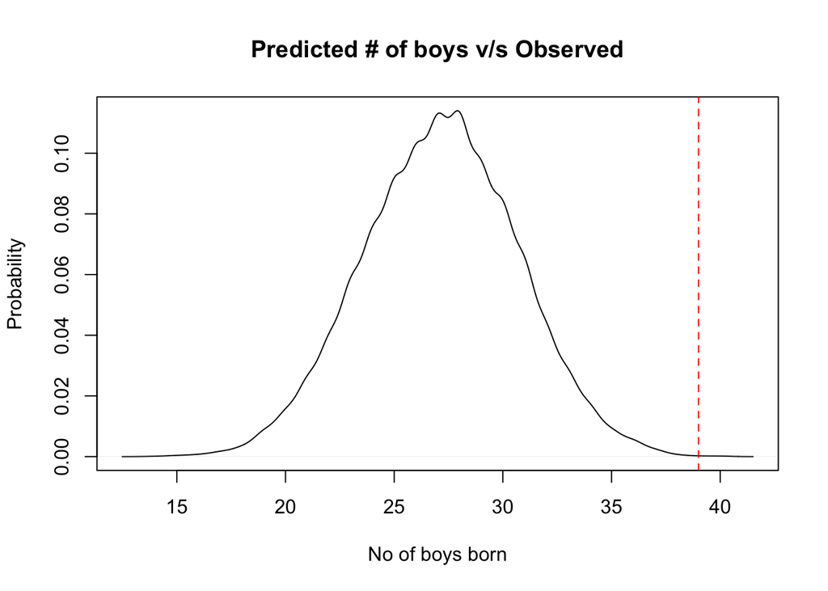

```r
plot(density(births_H5),
     xlab = "No of boys born", ylab = "Probability", main = "Predicted # of boys v/s Observed")
abline(v=actual_boys_2ndborn, col="red",lty=2)
```